# CoBrick-task

```python
import pandas as pd
import matplotlib.pyplot as plt
import statistics
import seaborn as sns
```

```python
df = pd.read_csv("dataset.csv")
df.head(3)
```

|  | Unnamed: 0 | incident_3 | incident_4 | incident_5 | incident_6 | incident_7 | incident_9 | incident_11 | incident_12 | incident_13 | normal_state_1 | normal_state_2 | normal_state_3 | normal_state_4 | normal_state_5 | normal_state_6 | normal_state_7 | normal_state_8 |
| --- | --- | --- | --- | --- | --- | --- | --- | --- | --- | --- | --- | --- | --- | --- | --- | --- | --- | --- |
| 0 | success_rate | [1.0, 1.0, 1.0, 1.0, 1.0, 1.0, 1.0, 1.0, 1.0, ... | [1.0, 1.0, 1.0, 1.0, 0.07692307692307694, 1.0,... | [1.0, 1.0, 1.0, 1.0, 0.010526315789473682, 0.0... | [1.0, 1.0, 1.0, 1.0, 1.0, 1.0, 1.0, 1.0, 1.0, ... | [1.0, 1.0, 1.0, 1.0, 1.0, 1.0, 1.0, 1.0, 1.0, ... | [1.0, 1.0, 1.0, 1.0, 1.0, 1.0, 0.5119047619047... | [1.0, 1.0, 1.0, 1.0, 1.0, 1.0, 0.7499999999999... | [1.0, 1.0, 1.0, 1.0, 1.0, 0.37499999999999994,... | [1.0, 1.0, 1.0, 1.0, 1.0, 1.0, 1.0, 1.0, 1.0, ... | [1.0, 1.0, 1.0, 1.0, 1.0, 1.0, 1.0, 1.0, 1.0, ... | [1.0, 1.0, 1.0, 1.0, 1.0, 1.0, 1.0, 1.0, 1.0, ... | [0.8387096774193549, 0.8387096774193549, 0.852... | [1.0, 1.0, 1.0, 1.0, 1.0, 1.0, 1.0, 1.0, 1.0, ... | NaN | NaN | NaN | NaN |
| 1 | ingress_request_rate | [3.1, 2.5, 2.5, 3.1, 3.7, 3.1, 3.1, 3.7, 3.1, ... | [23.5, 22.3, 26.4, 27.7, 28.9, 27.9, 31.8, 31.... | [370.8, 339.80194058217467, 328.7, 336.3, 200.... | [8.0, 4.9, 57.88582245690943, 54.6071678147149... | [1.3, 27.3, 0.6, 1.3, 2.8, 5.3, 1.1, 11.5, 223... | [190.15212169735787, 221.61339421613394, 189.7... | [3.8, 3.1, 3.7, 3.7, 2.5, 3.1, 4.0, 5.0, 2.4, ... | [1.0, 1.2, 1.4, 1.5, 0.8, 1.2, 1.0, 1.3, 1.2, ... | [2.5, 3.7, 3.7, 3.7, 2.3, 2.5, 2.5, 2.2, 3.7, ... | [3.1, 2.5, 2.5, 3.1, 3.7, 3.1, 3.1, 3.7, 3.1, ... | [2.0, 1.0, 1.3, 1.0, 1.2, 0.7, 1.4, 1.9, 1.7, ... | [0.6000300030003001, 1.0000900270081023, 0.300... | [15.2, 15.9, 16.1, 14.700000000000001, 15.7, 1... | [0.8999999999999999, 0.5, 1.2, 1.0, 0.60000000... | [0.8999999999999999, 0.5, 1.2, 1.0, 0.60000000... | [0.8999999999999999, 0.5, 1.2, 1.0, 0.60000000... | [0.8999999999999999, 0.5, 1.2, 1.0, 0.60000000... |
| 2 | latency_mean | [1.2307692307692308, 1.1538461538461537, 1.400... | [1.0227272727272727, 1.0731707317073167, 1.148... | [19.30769230769231, 20.56134157105031, 15.3596... | [0.6774193548387097, 0.7619047619047619, 13.60... | [3.7256097560975614, 6.437636761487964, 7.0989... | [4.371428571428571, 6.883040935672515, 4.66544... | [1.4999999999999998, 1.625, 1.4444444444444446... | [3.758620689655172, 3.6842105263157894, 5.4749... | [8.428571428571429, 6.624999999999999, 6.5, 7.... | [1.2307692307692308, 1.1538461538461537, 1.400... | [10.215469613259668, 3.1797752808988764, 3.941... | [4.06153846153846, 10.246575342465755, 16.1450... | [1.1800000000000002, 1.16, 1.274509803921569, ... | NaN | NaN | NaN | NaN |

## Preprocessing - unwrap and pivot

```python
df = df.rename(columns={'Unnamed: 0':'metrics'})
df = df.set_index('metrics')
df.head(3)
```

| metrics | incident_3 | incident_4 | incident_5 | incident_6 | incident_7 | incident_9 | incident_11 | incident_12 | incident_13 | normal_state_1 | normal_state_2 | normal_state_3 | normal_state_4 | normal_state_5 | normal_state_6 | normal_state_7 | normal_state_8 |
| --- | --- | --- | --- | --- | --- | --- | --- | --- | --- | --- | --- | --- | --- | --- | --- | --- | --- |
| success_rate | [1.0, 1.0, 1.0, 1.0, 1.0, 1.0, 1.0, 1.0, 1.0, ... | [1.0, 1.0, 1.0, 1.0, 0.07692307692307694, 1.0,... | [1.0, 1.0, 1.0, 1.0, 0.010526315789473682, 0.0... | [1.0, 1.0, 1.0, 1.0, 1.0, 1.0, 1.0, 1.0, 1.0, ... | [1.0, 1.0, 1.0, 1.0, 1.0, 1.0, 1.0, 1.0, 1.0, ... | [1.0, 1.0, 1.0, 1.0, 1.0, 1.0, 0.5119047619047... | [1.0, 1.0, 1.0, 1.0, 1.0, 1.0, 0.7499999999999... | [1.0, 1.0, 1.0, 1.0, 1.0, 0.37499999999999994,... | [1.0, 1.0, 1.0, 1.0, 1.0, 1.0, 1.0, 1.0, 1.0, ... | [1.0, 1.0, 1.0, 1.0, 1.0, 1.0, 1.0, 1.0, 1.0, ... | [1.0, 1.0, 1.0, 1.0, 1.0, 1.0, 1.0, 1.0, 1.0, ... | [0.8387096774193549, 0.8387096774193549, 0.852... | [1.0, 1.0, 1.0, 1.0, 1.0, 1.0, 1.0, 1.0, 1.0, ... | NaN | NaN | NaN | NaN |
| ingress_request_rate | [3.1, 2.5, 2.5, 3.1, 3.7, 3.1, 3.1, 3.7, 3.1, ... | [23.5, 22.3, 26.4, 27.7, 28.9, 27.9, 31.8, 31.... | [370.8, 339.80194058217467, 328.7, 336.3, 200.... | [8.0, 4.9, 57.88582245690943, 54.6071678147149... | [1.3, 27.3, 0.6, 1.3, 2.8, 5.3, 1.1, 11.5, 223... | [190.15212169735787, 221.61339421613394, 189.7... | [3.8, 3.1, 3.7, 3.7, 2.5, 3.1, 4.0, 5.0, 2.4, ... | [1.0, 1.2, 1.4, 1.5, 0.8, 1.2, 1.0, 1.3, 1.2, ... | [2.5, 3.7, 3.7, 3.7, 2.3, 2.5, 2.5, 2.2, 3.7, ... | [3.1, 2.5, 2.5, 3.1, 3.7, 3.1, 3.1, 3.7, 3.1, ... | [2.0, 1.0, 1.3, 1.0, 1.2, 0.7, 1.4, 1.9, 1.7, ... | [0.6000300030003001, 1.0000900270081023, 0.300... | [15.2, 15.9, 16.1, 14.700000000000001, 15.7, 1... | [0.8999999999999999, 0.5, 1.2, 1.0, 0.60000000... | [0.8999999999999999, 0.5, 1.2, 1.0, 0.60000000... | [0.8999999999999999, 0.5, 1.2, 1.0, 0.60000000... | [0.8999999999999999, 0.5, 1.2, 1.0, 0.60000000... |
| latency_mean | [1.2307692307692308, 1.1538461538461537, 1.400... | [1.0227272727272727, 1.0731707317073167, 1.148... | [19.30769230769231, 20.56134157105031, 15.3596... | [0.6774193548387097, 0.7619047619047619, 13.60... | [3.7256097560975614, 6.437636761487964, 7.0989... | [4.371428571428571, 6.883040935672515, 4.66544... | [1.4999999999999998, 1.625, 1.4444444444444446... | [3.758620689655172, 3.6842105263157894, 5.4749... | [8.428571428571429, 6.624999999999999, 6.5, 7.... | [1.2307692307692308, 1.1538461538461537, 1.400... | [10.215469613259668, 3.1797752808988764, 3.941... | [4.06153846153846, 10.246575342465755, 16.1450... | [1.1800000000000002, 1.16, 1.274509803921569, ... | NaN | NaN | NaN | NaN |

```python
df = df.unstack(level=-1)
df.head(3)
```

```
            metrics
incident_3  success_rate            [1.0, 1.0, 1.0, 1.0, 1.0, 1.0, 1.0, 1.0, 1.0, ...
            ingress_request_rate    [3.1, 2.5, 2.5, 3.1, 3.7, 3.1, 3.1, 3.7, 3.1, ...
            latency_mean            [1.2307692307692308, 1.1538461538461537, 1.400...
dtype: object
```

```python
df = df.unstack(level=-1)
df.head(3)
```

| metrics | success_rate | ingress_request_rate | latency_mean | tcp_connections_open | cpu_usage | memory_usage | request_rate | ingress_reload |
| --- | --- | --- | --- | --- | --- | --- | --- | --- |
| incident_3 | [1.0, 1.0, 1.0, 1.0, 1.0, 1.0, 1.0, 1.0, 1.0, ... | [3.1, 2.5, 2.5, 3.1, 3.7, 3.1, 3.1, 3.7, 3.1, ... | [1.2307692307692308, 1.1538461538461537, 1.400... | [2.0, 3.0, 2.0, 2.0, 2.0, 2.0, 2.0, 2.0, 2.0, ... | [0.0005824917135290436, 0.000704179662361493, ... | [2684245.3333333335, 2742954.6666666665, 27538... | [0.8, 0.8, 0.8999999999999999, 0.8, 0.89999999... | [0.0, 0.0, 0.0, 0.0, 0.0, 0.0, 0.0, 0.0, 0.0, ... |
| incident_4 | [1.0, 1.0, 1.0, 1.0, 0.07692307692307694, 1.0,... | [23.5, 22.3, 26.4, 27.7, 28.9, 27.9, 31.8, 31.... | [1.0227272727272727, 1.0731707317073167, 1.148... | [5.0, 4.0, 4.0, 3.0, 4.0, 10.0, 10.0, 3.0, 3.0... | [0.011159454580441007, 0.0054166197140563645, ... | [52509354.666666664, 52637696.0, 51752960.0, 3... | [4.3999999999999995, 4.1, 4.699999999999999, 4... | [0.0, 0.0, 0.0, 0.0, 0.0, 0.0, 0.0, 0.0, 0.0, ... |
| incident_5 | [1.0, 1.0, 1.0, 1.0, 0.010526315789473682, 0.0... | [370.8, 339.80194058217467, 328.7, 336.3, 200.... | [19.30769230769231, 20.56134157105031, 15.3596... | [49.0, 27.0, 16.0, 11.0, 245.0, 184.0, 17.0, 5... | [0.10528297275402682, 0.09785424063176727, 0.1... | [73374378.66666667, 73519104.0, 73920512.0, 74... | [64.45837063563114, 57.06248744223428, 54.6148... | [0.0, 0.0, 0.0, 0.0, 0.0, 0.0, 0.0, 0.0, 0.0, ... |

## Dataset statistics - nans

```python
df.isna().sum()
```

```
metrics
success_rate            4
ingress_request_rate    0
latency_mean            4
tcp_connections_open    4
cpu_usage               2
memory_usage            2
request_rate            4
ingress_reload          0
dtype: int64
```

```python
df.isna().sum(axis = 1)
```

```
incident_3        0
incident_4        0
incident_5        0
incident_6        0
incident_7        0
incident_9        0
incident_11       0
incident_12       0
incident_13       0
normal_state_1    0
normal_state_2    0
normal_state_3    2
normal_state_4    2
normal_state_5    4
normal_state_6    4
normal_state_7    4
normal_state_8    4
dtype: int64
```

We can see that none of incidents contains nans.

## Processing

```python
def string_list_to_list_of_floats(string_list):
    '''
    Function transforms string containg list of numbers to list of floats or empty list
    Params: string_list[string] - string to convert
    Returns: [list] of [float]
    '''
    if pd.isnull(string_list):
        return []
    else:
        string_list = string_list.replace("[", "")
        string_list = string_list.replace("]", "")
        float_list = list(map(float, string_list.split(',')))
        return float_list
```

```python
df = df.applymap(string_list_to_list_of_floats)
```

```python
def get_plots_for_row(df, case):
    '''
    Function plot every cell of given case - every cell is a list of floats (or empty list).
    Params: df[pandas.DataFrame] - whole dataframe containg data to be ploted(and especially given case)
    case[string] - given case to plot only chosen row of data
    Returns: nothing
    '''
    fig, axs = plt.subplots(3, 3, figsize=(15,15))
    fig.suptitle(case)
    for i in range(len(df.columns)):
        metric = df.columns[i]
        data_for_plot = df.loc[case, metric]
        axs[i//3, i%3].plot(data_for_plot)
        axs[i//3, i%3].set_ylabel(metric)
```

```python
def get_plots_for_each_case(df):
    '''
    Function to plot every case using get_plots_for_row().
    Params: df[pandas.DataFrame] - whole dataframe containg data to be ploted
    Returns: nothing
    '''
    for i in range(len(df.index)):
        case = df.index[i]
        get_plots_for_row(df, case)
```

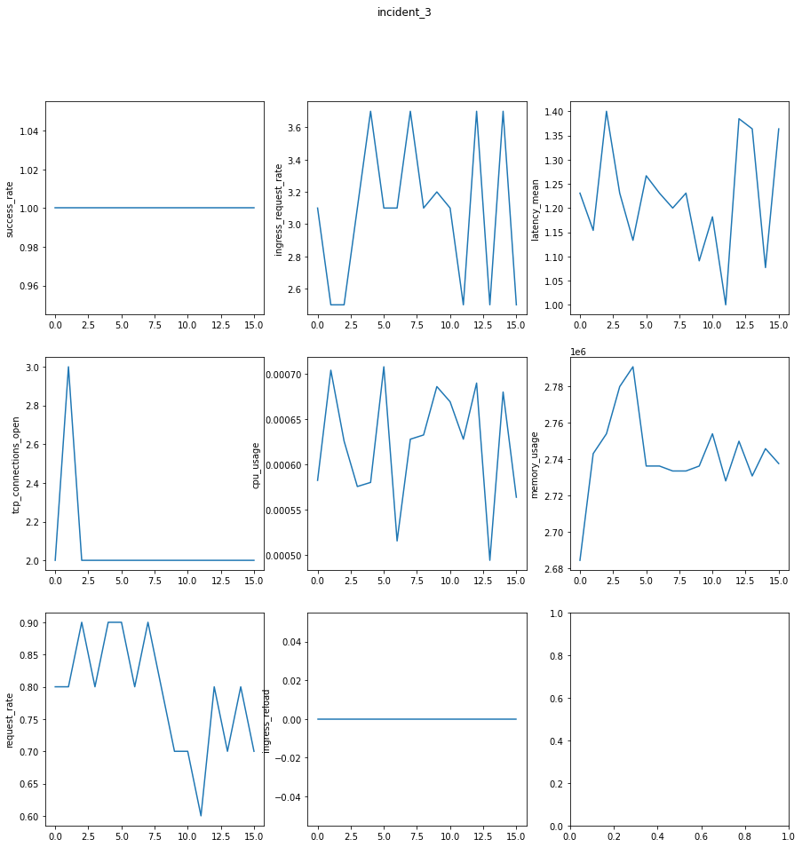

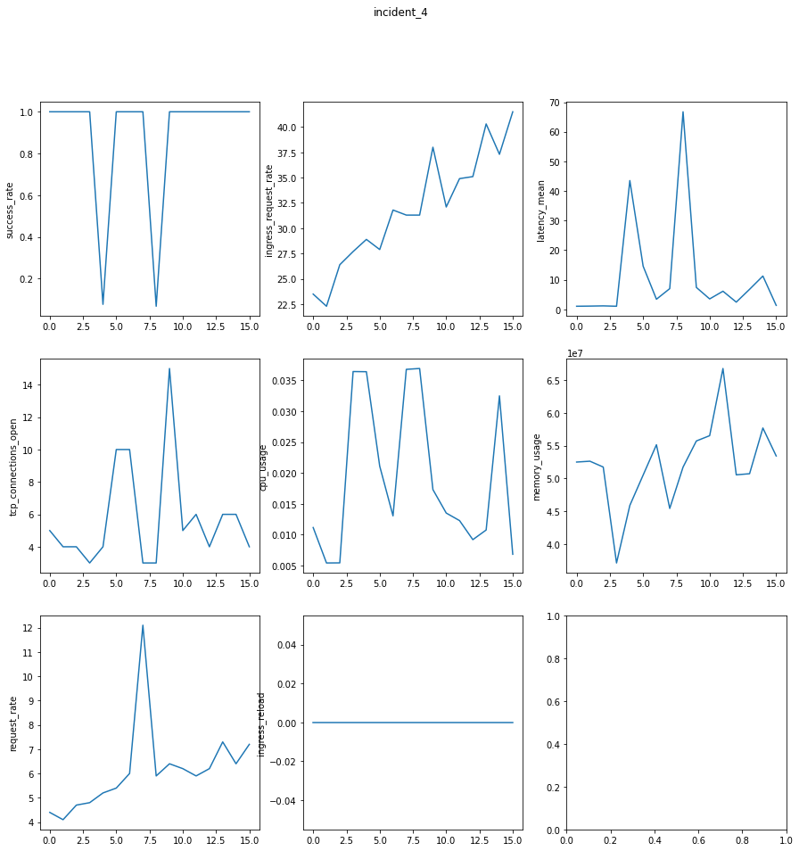

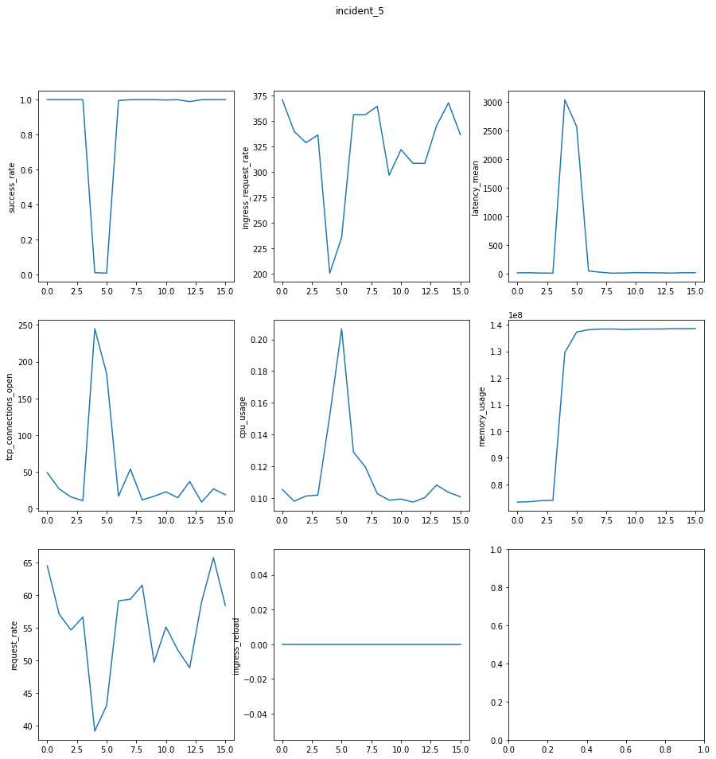

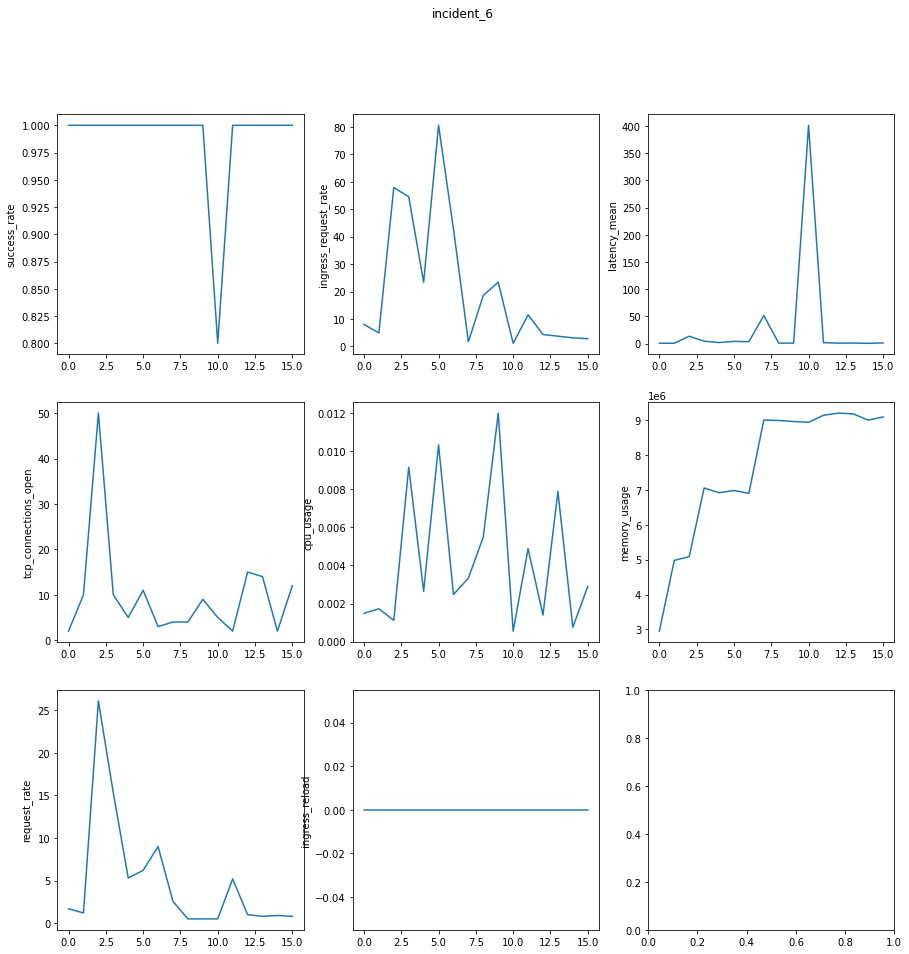

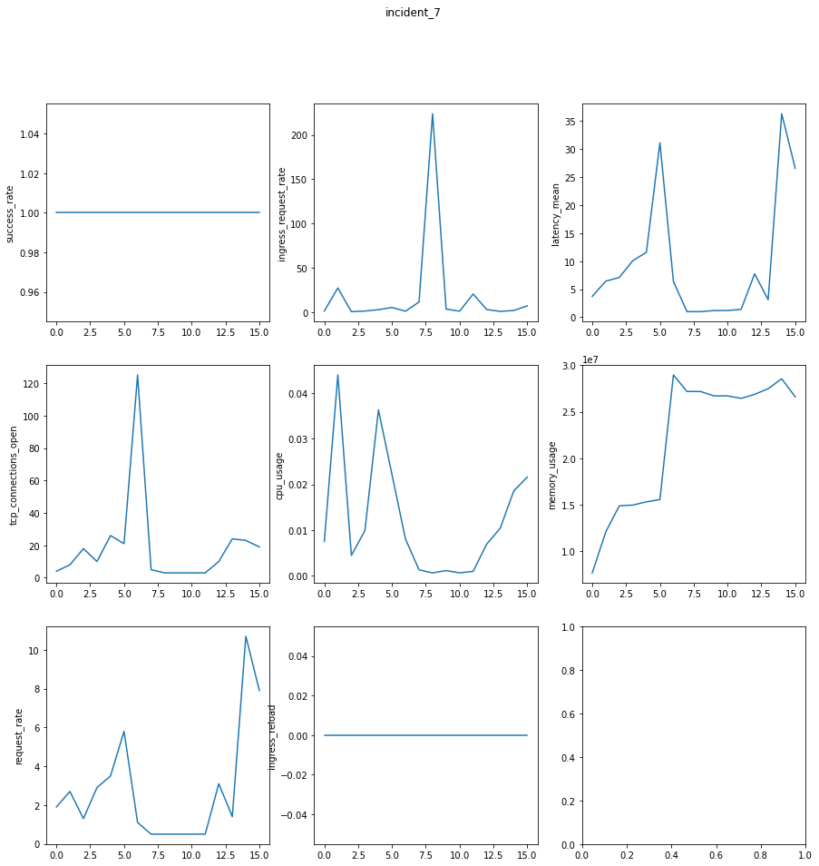

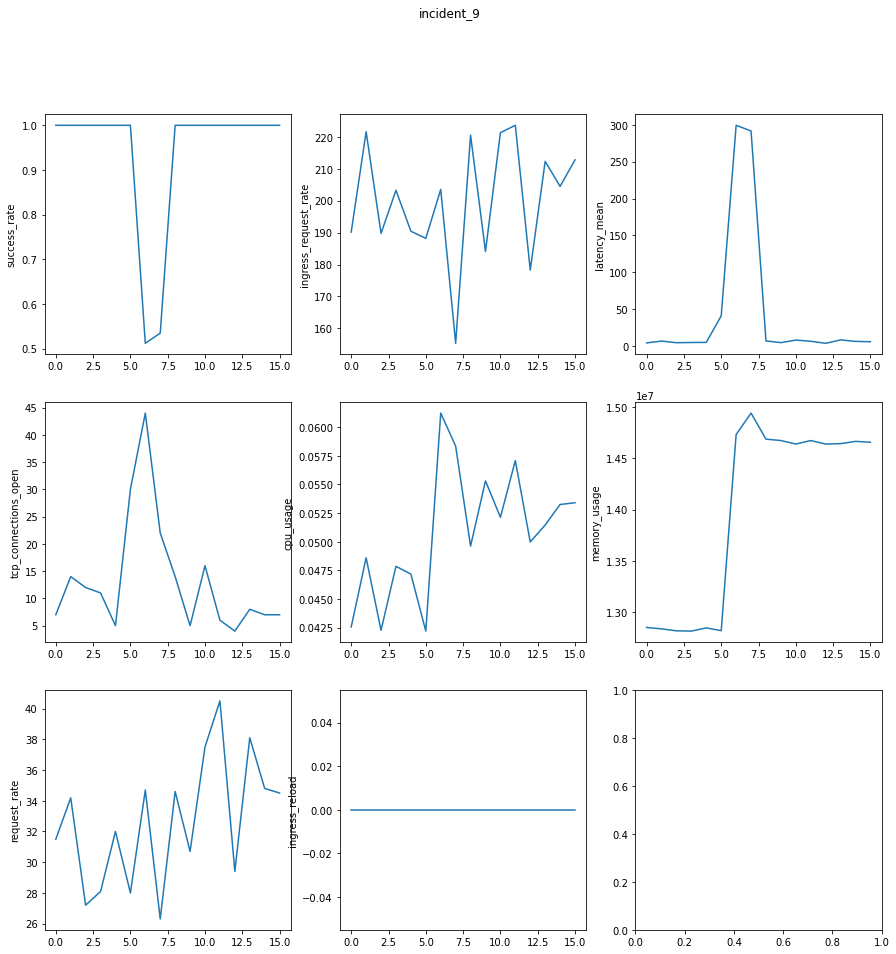

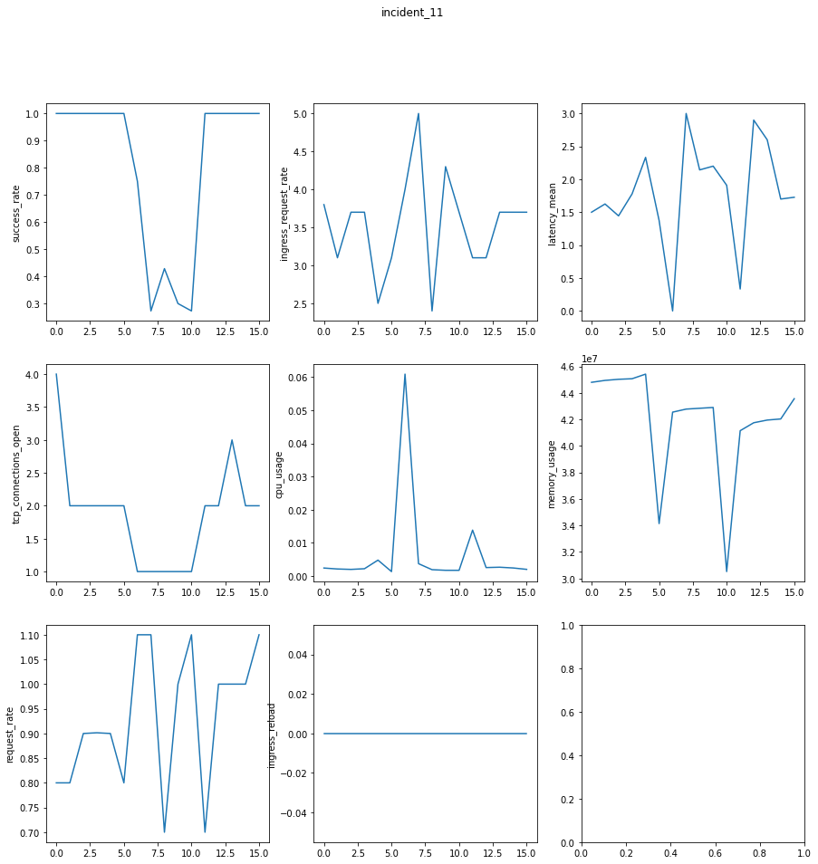

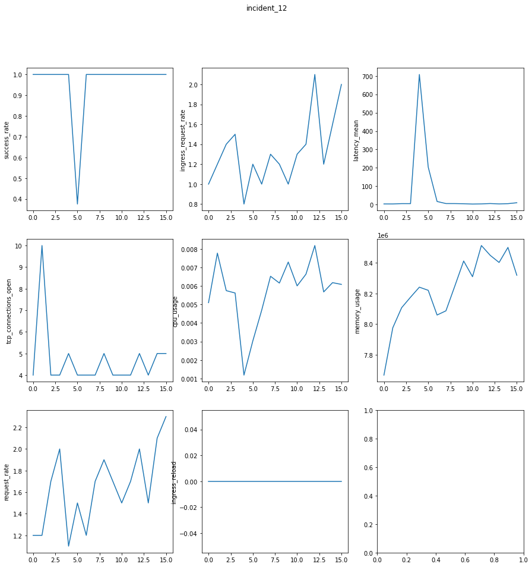

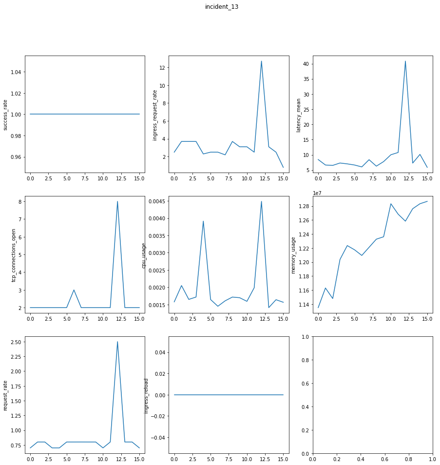

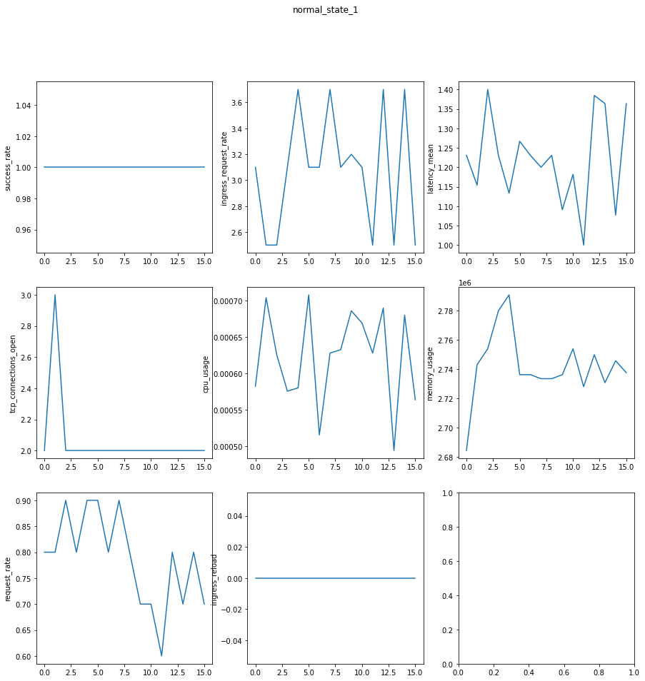

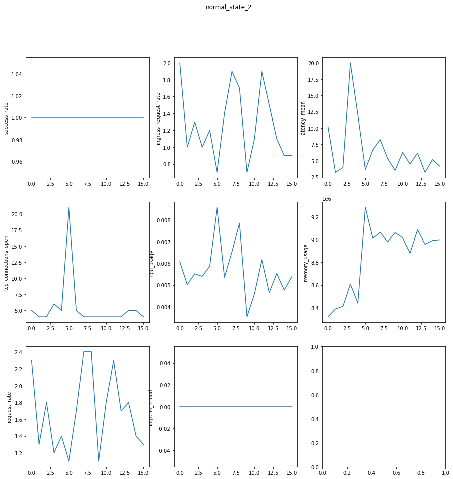

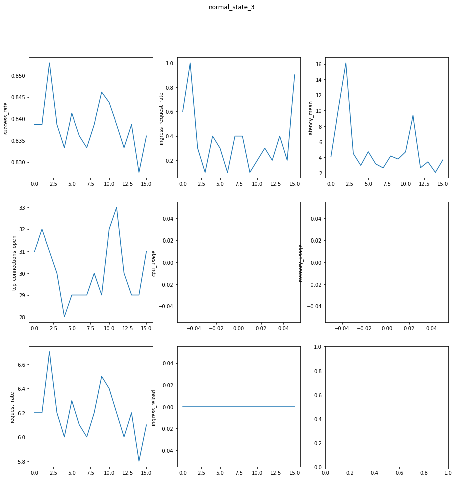

[5 more figures not shown]

```python
get_plots_for_each_case(df)
```

Plots above doesn't provide much information...

```python
def range_from_list(list_cell):
    return max(list_cell) - min(list_cell)
```

```python
def mean_from_list(list_cell):
    return statistics.mean(list_cell)
```

```python
def stdev_from_list(list_cell):
    return statistics.stdev(list_cell)
```

```python
def max_over_min(list_cell):
    try:
        return max(list_cell)/min(list_cell)
    except(ZeroDivisionError):
        return 0
```

```python
def is_increasing(list_cell):
    return pd.Series(list_cell).is_monotonic_increasing
```

```python
def is_decreasing(list_cell):
    return pd.Series(list_cell).is_monotonic_decreasing
```

```python
def get_metric_from_list(list_cell, metric_function):
    '''
    Function calculating some metric from list (if not empty).
    Params: listcell[list] of [floats] - list to be aggregated
    Returns: metric[float] - aggregation to be calculated // OR None if list is empty
    '''
    if len(list_cell) == 0:
        return None
    else:
        return metric_function(list_cell)
```

```python
def get_df_modified_by_function(df, function):
    return df.applymap(lambda x: get_metric_from_list(x, function))
```

```python
df_ranges = get_df_modified_by_function(df, range_from_list)
df_means = get_df_modified_by_function(df, mean_from_list)
df_stdev = get_df_modified_by_function(df, stdev_from_list)
df_max_over_min = get_df_modified_by_function(df, max_over_min)
df_is_increasing = get_df_modified_by_function(df, is_increasing)
df_is_decreasing = get_df_modified_by_function(df, is_decreasing)
```

Number of detected monocities is insignificant, that's why I don't analyse them. But I've checked it :)

## plots of statistics

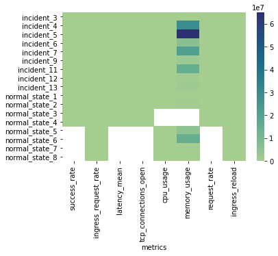

```python
sns.heatmap(df_ranges, cmap="crest")
```

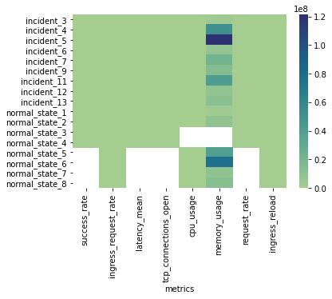

```python
sns.heatmap(df_means, cmap="crest")
```

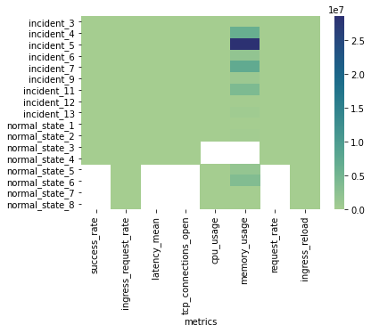

```python
sns.heatmap(df_stdev, cmap="crest")
```

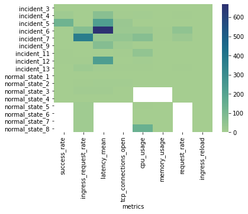

```python
sns.heatmap(df_max_over_min, cmap="crest")
```

# Normalization

Plots above doesn't provide much information due to disproportionate values of metrics. That's why i decided to normalize those metrics.

```python
def get_normalized_df(df):
    return (df-df.min())/(df.max()-df.min())
```

```python
normalized_df_stdev=get_normalized_df(df_stdev)
normalized_df_means=get_normalized_df(df_means)
normalized_df_ranges=get_normalized_df(df_ranges)
normalized_df_max_over_min=get_normalized_df(df_max_over_min)
```

## Plots of normalized statistics

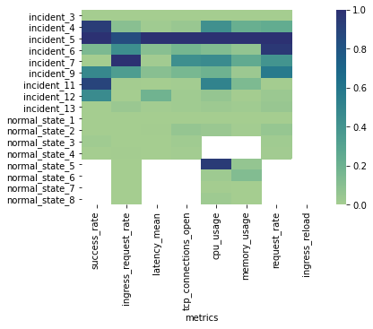

```python
sns.heatmap(normalized_df_stdev, cmap="crest")
```

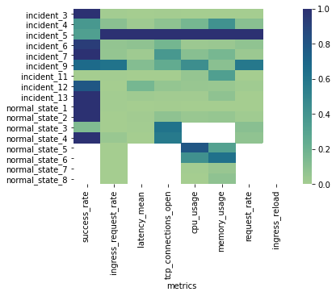

```python
sns.heatmap(normalized_df_means, cmap="crest")
```

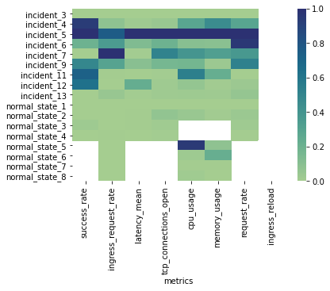

```python
sns.heatmap(normalized_df_ranges, cmap="crest")
```

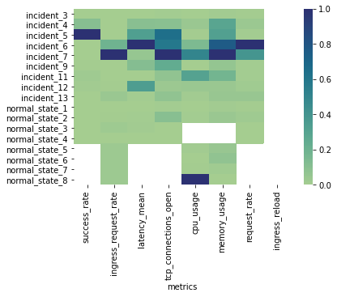

```python
sns.heatmap(normalized_df_max_over_min, cmap="crest")
```

## Coefficient of variance coef_of_var

-standard deviation relative to mean of sample

```python
df_coef_of_var = df_stdev/df_means
```

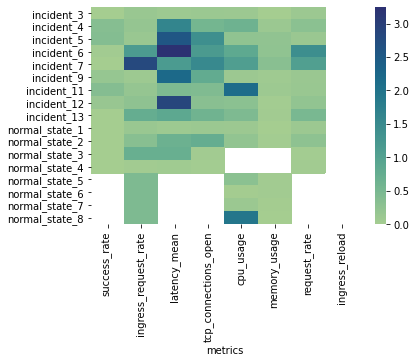

```python
sns.heatmap(df_coef_of_var, cmap="crest")
```

# Variability of metrics for every case

To get to know how is the variability of metrics in each case we sum cofficient of variance of each metric for every case.

```python
sum_rows = pd.DataFrame(df_coef_of_var.sum(axis=1))
```

```python
sum_rows
```

|  | 0 |
| --- | --- |
| incident_3 | 0.594430 |
| incident_4 | 3.802189 |
| incident_5 | 5.147259 |
| incident_6 | 8.174893 |
| incident_7 | 7.991037 |
| incident_9 | 3.607796 |
| incident_11 | 3.851559 |
| incident_12 | 4.165670 |
| incident_13 | 3.228194 |
| normal_state_1 | 0.594430 |
| normal_state_2 | 2.281494 |
| normal_state_3 | 1.530962 |
| normal_state_4 | 0.177103 |
| normal_state_5 | 0.796661 |
| normal_state_6 | 0.516695 |
| normal_state_7 | 0.585799 |
| normal_state_8 | 2.403756 |

Numbers above presents, that sum of coefficients of variance is less or equal 2.4 for normal cases. For incidents, this metric is more or equal 3.2 (except incident_3, which looks quite normal).

Next, let's check how is this sums of coefficients represented in each type of case (incident/normal).

```python
df_sum_rows['type'] = df_sum_rows.index.to_series().map(lambda x: 'incident' if x.startswith('incident_') else 'normal')
```

# Descriptive stats

Statistics below presents, that metrics in normal_states have less variability - mean is 4 times smaller, stddev is 3 times smaller.

```python
df_sum_rows.groupby(['type']).describe()
```

| type | 0 count | 0 mean | 0 std | 0 min | 0 25% | 0 50% | 0 75% | 0 max |
| --- | --- | --- | --- | --- | --- | --- | --- | --- |
| incident | 9.0 | 4.507003 | 2.366349 | 0.594430 | 3.607796 | 3.851559 | 5.147259 | 8.174893 |
| normal | 8.0 | 1.110863 | 0.852265 | 0.177103 | 0.568523 | 0.695546 | 1.718595 | 2.403756 |

# Summary

In the given dataset there are 9 incidents and 8 normal cases presented.

There are no main metrics indicating incident, but it is possible to point the most extreme incident - incident_5. It stands out from rest of incindents looking at normalized plots. Of course success-rate is highly connected with incident detecting, but it's somehow self-explaining variable.

The analysis was focused and driven by variety of measured metrics.

Calculated metrics (standard deviation, mean, range, max/min) presented on plots`#Plots of normalized statistics` show that variety is bigger in incidents than in normal_cases.

It is mostly visible on `#Variability of metrics` where coefficients of variance of each metric are summed up for each case. `Sum of cofficient of variance` defines the type(incident/normal) with high certainty.